# Homework-4

Francesca Pecorari

2023-11-30

## Creazione piano per RSM

Creare un piano di Box-Behnken in ordine standard per per l’ottimizzazione della viscosità dinamica di un polimero considerando i seguenti 3 fattori: “Temp” (150,175,200), Agitation Rate (5,7.5,10), Pressure (15,20,25) e 3 punti al centro per un totale di 15 esperimenti

```r
library("Vdgraph")
library("rsm")

my_BB <- bbd(3, n0 = 3, coding = list( x1 ~ (Temp - 150)/25, x2 ~ (Rate - 7.5)/2.5, x3 ~ (Polish - 20)/5),
             randomize = F)
```

## Aggiunta variabile risposta

Aggiungere al data.frame del piano creato precedentemente una colonna con la variabile risposta “Viscosità (cP)” = [535,580,596,563,645,458,350,600,595,648,532,656,653,599,620].

```r
Viscosità = c(535,580,596,563,645,458,350,600,595,648,532,656,653,599,620)
my_BB<-cbind(my_BB, Viscosità)
```

## Analisi piano

Creare un modello di secondo ordine per l’analisi del piano, visulizzare le superfici di risposta. Quali condizioni operative raccomandereste se l’obiettivo della sperimentazione fosse quello di ottenere una viscosità più vicina possibile a 600 cP ?

```r
Vdgraph(my_BB[,3:5])
```

```
## number of design points= 15
## number of factors= 3
```

```
##           Radius   Maximum   Minimum   Average
##  [1,] 0.00000000  5.000000  5.000000  5.000000
##  [2,] 0.08660254  4.984477  4.984445  4.984458
##  [3,] 0.17320508  4.939125  4.938625  4.938825
##  [4,] 0.25980762  4.867602  4.865070  4.866083
##  [5,] 0.34641016  4.776000  4.768000  4.771200
##  [6,] 0.43301270  4.672852  4.653320  4.661133
##  [7,] 0.51961524  4.569125  4.528625  4.544825
##  [8,] 0.60621778  4.478227  4.403195  4.433208
##  [9,] 0.69282032  4.416000  4.288000  4.339200
## [10,] 0.77942286  4.400727  4.195695  4.277708
## [11,] 0.86602540  4.453125  4.140625  4.265625
## [12,] 0.95262794  4.596352  4.138820  4.321833
## [13,] 1.03923048  4.856000  4.208000  4.467200
## [14,] 1.12583302  5.260109  4.367570  4.724583
## [15,] 1.21243557  5.839134  4.638625  5.118825
## [16,] 1.29903811  6.625977  5.043945  5.676758
## [17,] 1.38564065  7.656000  5.608000  6.427200
## [18,] 1.47224319  8.967020  6.356945  7.400958
## [19,] 1.55884573 10.599125  7.318625  8.630825
## [20,] 1.64544827 12.595170  8.522570 10.151583
## [21,] 1.73205081 15.000000 10.000000 12.000000
```

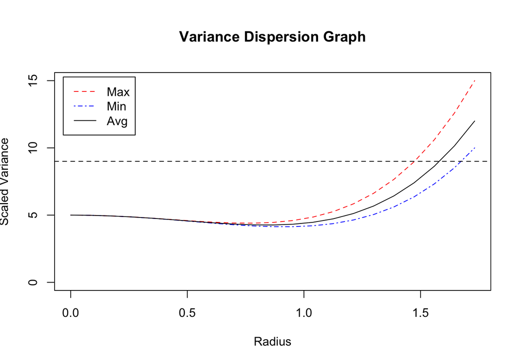

```r
abline(h=9, lty=2)
```

Creiamo quindi un modello di secondo ordine

```r
mod <-rsm(Viscosità ~ SO(x1,x2,x3), data=my_BB)

summary(mod)
```

```
##
## Call:
## rsm(formula = Viscosità ~ SO(x1, x2, x3), data = my_BB)
##
##             Estimate Std. Error t value  Pr(>|t|)
## (Intercept)  624.000     18.652 33.4539 4.487e-07 ***
## x1             9.375     11.422  0.8208  0.449128
## x2            27.625     11.422  2.4185  0.060228 .
## x3           -26.000     11.422 -2.2763  0.071874 .
## x1:x2        -19.500     16.154 -1.2072  0.281356
## x1:x3        109.250     16.154  6.7632  0.001074 **
## x2:x3         17.750     16.154  1.0988  0.321915
## x1^2         -75.000     16.813 -4.4608  0.006636 **
## x2^2          19.500     16.813  1.1598  0.298496
## x3^2         -35.750     16.813 -2.1263  0.086809 .
## ---
## Signif. codes:  0 '***' 0.001 '**' 0.01 '*' 0.05 '.' 0.1 ' ' 1
##
## Multiple R-squared:  0.945,  Adjusted R-squared:  0.846
## F-statistic: 9.544 on 9 and 5 DF,  p-value: 0.0115
##
## Analysis of Variance Table
##
## Response: Viscosità
##                 Df Sum Sq Mean Sq F value   Pr(>F)
## FO(x1, x2, x3)   3  12216  4072.1  3.9014 0.088473
## TWI(x1, x2, x3)  3  50524 16841.2 16.1352 0.005278
## PQ(x1, x2, x3)   3  26913  8970.9  8.5949 0.020359
## Residuals        5   5219  1043.7
## Lack of fit      3   3737  1245.6  1.6809 0.394113
## Pure error       2   1482   741.0
##
## Stationary point of response surface:
##         x1         x2         x3
##  2.1849596 -0.8713709  2.7586015
##
## Eigenanalysis:
## eigen() decomposition
## $values
## [1]   20.922869    2.520763 -114.693632
##
## $vectors
##           [,1]       [,2]       [,3]
## x1 -0.02739155  0.5811826  0.8133121
## x2  0.99128775 -0.0890686  0.0970329
## x3  0.12883440  0.8088842 -0.5736794
```

Facendo il summary del modello notiamo che:

- i coefficienti di x2 e x3 sono significativi
- il coefficiente dell’ interazione tra x1 e x3 è significativo
- i coefficienti dei termini quadratici x1 e x3 sono significativi
- abbaimo un p-value significativo per le interazioni e per i modelli quadratici
- il lack of fit non sembra essere significativo
- guardando i punti stazionari notiamo che i valori di x1 e x3 sono positivi, mentre quello di x2 è negativo
- guardando gli autovalori si nota che non tutti sono valori negativi e che quindi questo potrebbe non essere un massimo effettivo

Visualizziamo e commentiamo le superfici di isorisposta

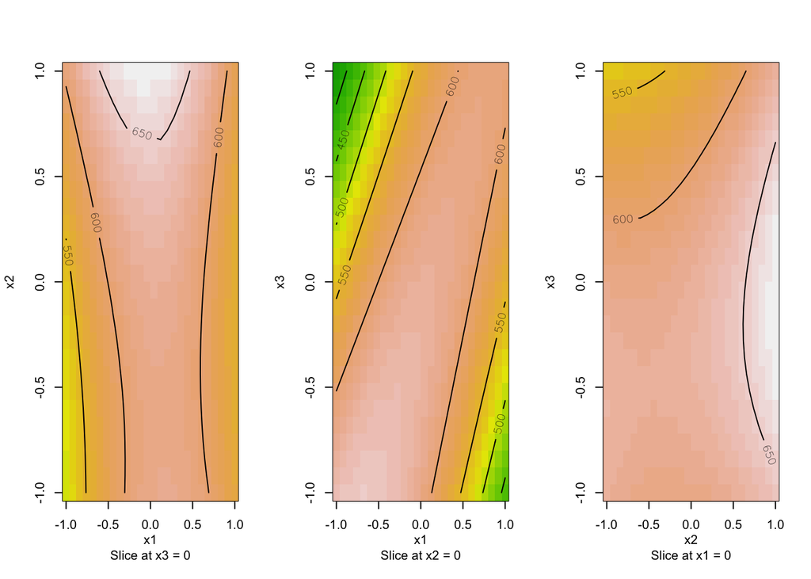

```r
# ci permette di visualizzare le curve di isorisposta e lo fa a coppie, per visualizzarle tutte uso par
par(mfrow= c(1,3))
# contour(mod ,~x1+x2+x3) - senza colori
contour(mod, ~ x1 + x2 + x3, image = TRUE)
```

```
## Near-stationary-ridge situation detected -- stationary point altered
##  Change 'threshold' if this is not what you intend
```

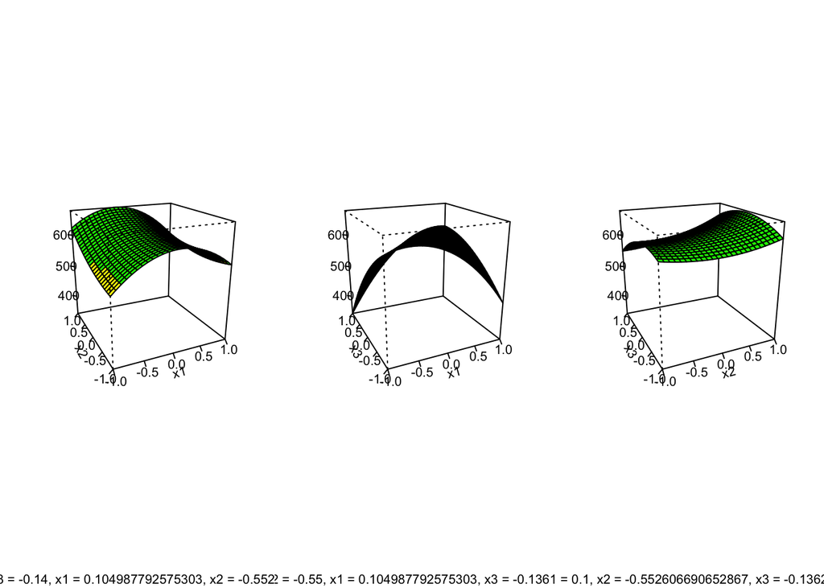

```r
# superfici di risposta che ci permettono di avere una visualizzazione diversa
# il terzo fattore viene fissato a un valore scelto ( in questo caso al punto stazioneario valore di ottimo)
persp(mod,~x1+x2+x3, at=xs(mod), col= c("red", "yellow", "green"))
```

Vediamo che le curve ottenute nel contour plot non sono concentriche, come vorremmo che fossero se avessimo trovato un massimo, vuol dire che siamo ancora lontani dall’obiettivo finale. Anche la rappresentazione tridimensionale ci indica che non ci troviamo vicino a un massimo e che probabilmente abbaimo incontrato un punto di sella.

Visti i risultati ottenuti sarebbe opportuno calcolare la direzione di ascesa più ripida utilizzando la ridge analysis e ricominciare il processo dall’inizio, magari aggiungendo un secondo blocco di esperimenti.